# Example P.2 Oh Say Can You Sing?

Last updated Thursday, August 17, 2023 @ 03:02 PM

## STEP 1: Ask a Research Question

[figure not shown]

How long does it take performers to sing the national anthem? (*People actually bet money on this! But practically speaking, Super Bowl planners would also want to know. Time is $ in the big game.*)

## STEP 2: Design a Study / Collect Data

**Table P.2.1** Selected data about Super Bowl performances of the Star Spangled Banner from 2010 to 2019

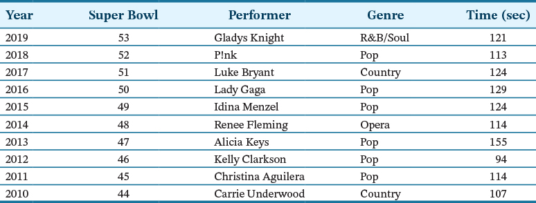

The [National Anthem dataset](http://www.isi-stats.com/isi/data/prelim/NationalAnthemTimes.txt) contains data from 1980 to 2019. We can explore it using the [Descriptive Statistics applet](http://www.isi-stats.com/isi2nd/ISIapplets2021.html), which contains updated data (*SB Anthems*) for years after 2019.

## The SB Anthems Dataset

The applet dataset includes more variables than the example shown in the textbook.

- `Year`: the year of the Super Bowl
- `SuperBowl`: the number of the Super Bowl
- `Performer`: name of the performer(s)
- `Genre`: the performer’s musical genre
- `Genre2`: different genre classification (includes “other”)
- `Time`: anthem length in seconds (*source not specified*)
- `Sex`: sex of the performer(s) — male, female, mixed
- `sbdTime`: anthem length from sportsbettingdime.com

## Observational Units and Variables

The textbook states, “So, we collected data on the length of the performance of the national anthem preceding the National Football League’s Super Bowl for games from 1980 (Super Bowl 14) to 2019 (Super Bowl 53). Based on the dataset description in the book and **Table P.2.1** …

- What are the *observational units* in this dataset?
- What are the *categorical* variables in this dataset?
- What are the *quantitative* variables in this dataset?
- What are the units of measurement associated with each of the quantitative variables?
- How can we explore the data to produce useful information?

## Describing a Variable’s Distribution

**Categorical Variables**

- frequency / relative frequency

*Summaries based on counting how many times categories occur.*

**Quantitative Variables**

- **shape** (symmetric? skewed? mound-shaped? clusters?)
- **center** (middle or “typical” value/values; mean and median)
- **spread** (more properly called variability; SD and range)
- **unusual observations** (was someone very quick/very slow?)

*Shape, center, and spread describe the pattern of the distribution. Unusual observations are deviations from the pattern.*

## What Makes an Effective Graph?

- Let the data tell the story.
- Include appropriate labels for axes, including what is being measured and any associated units of measurement.
- Use an amount of “ink” that is proportional to the information involved. Less is often more!
- Include a title and/or a figure caption.
- Scale any quantitative axes appropriately (e.g., it can be very misleading if a quantitative axis does not start at zero).

Ideally a graph should be a reasonably stand-alone method of conveying information.

## STEP 3: Explore the Data

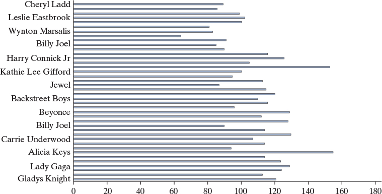

Why is this graph *not* effective for exploring the question “How long does it take performers to sing the national anthem?” (*Go back and check the guidelines for an effective graph.*)

## A Better Representation

Length of Superbowl National Anthems (1980 to 2019)

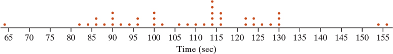

- What kind of plot is this?
- What does each dot represent?
- Can you describe the variable distribution?
- What are the measurement units? Why do they matter?

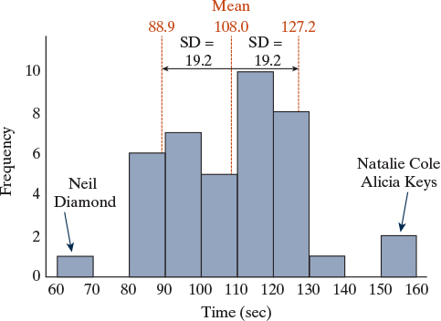

- What kind of plot is this?
- What does each bar represent?
- Can you describe the variable distribution?

## What is the Distribution?

- **shape**: relatively symmetric, perhaps bimodal (two peaks)
- **center**: the mean time is 108.0 seconds (1 min and 48 sec); Carrie Underwood’s rendition was about “average” length
- **spread**: the SD is 19.2 sec and the range is 156 – 64 = 92 sec
- **unusual observations**: There are three performances in this dataset that stand out. Neil Diamond appears to have sung an unusually short time at 64 seconds. On the other side of the distribution, both Natalie Cole and Alicia Keys performed for about 150 seconds (two and a half minutes).

Are there any other variables that can help us explain/predict why national anthem performances at the Super Bowl vary in terms of the length of time they last?

## Time Grouped by Sex*

We can use a categorical variable to provide more information.

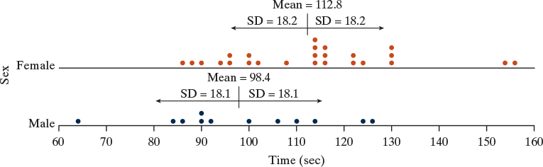

**We often run into binary gender groupings in research, especially when working with older observations. It may also be true that all performers so far identify solely as male or female. What might be some of the consequences if someone is misclassified?*

## Time Grouped by Genre

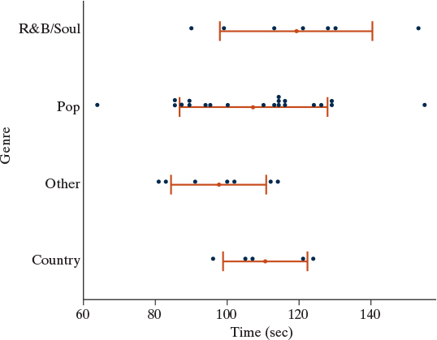

For which genre might we be able to make the best estimates? Why do you think so? (*Hint: Does one have more similar times?*)

## Time Grouped by Sex *and* Genre

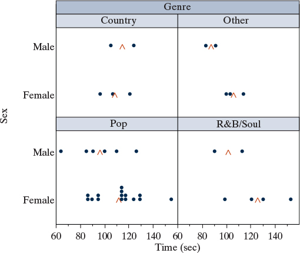

Are any sex-based differences in length the same within genres?

## Has Length Changed over the Years?

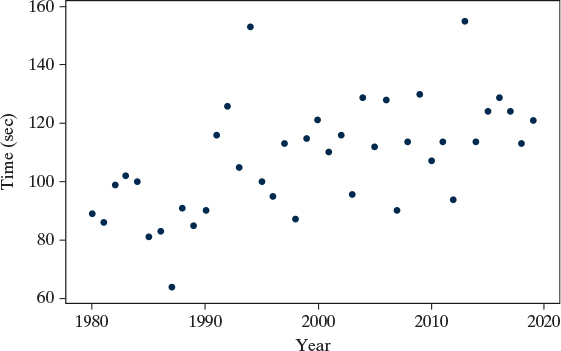

To create this kind of plot, we need to paste the dataset into the [Correlation/Regression applet](http://www.isi-stats.com/isi2nd/ISIapplets2021.html).

## Let’s Add Some More Information

Do you see a trend in anthem length over the years? What is it?

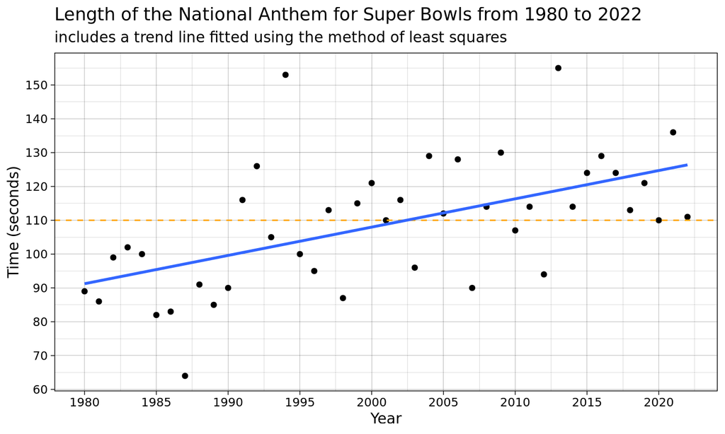

## Observations Grouped by Sex

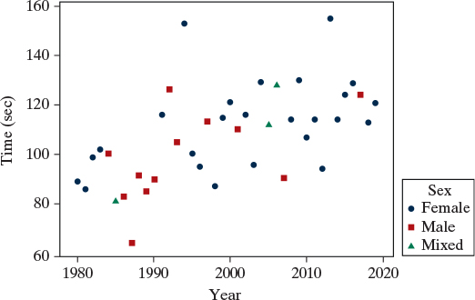

Can we detect any other patterns here? Overall, what do these graphs and statistics tell us? What other data would you like to have to help explain the amount of time?

## Another Visualization of the Data

Do you see a trend in performer sex over the years? What is it?

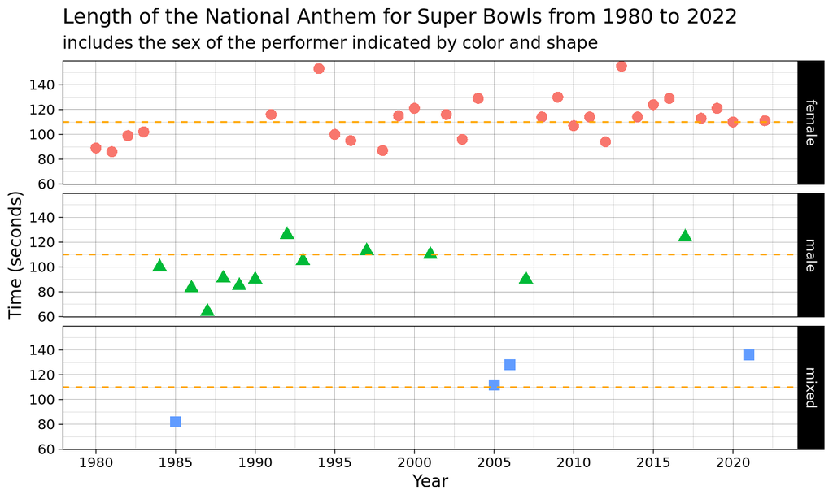